# Psychotherapy Study

Roberts Klotins and Thomas Gargot

February, 28th 2016

# Presentation

## Presentations of the survey

### Past

- “The EFPT Psychotherapy working Group and its Survey on Psychotherapy Training 2013-2015” was presented at the [Royal College of Psychiatrists](http://www.rcpsych.ac.uk/pdf/CALC_MedPsych2015confbooklet.pdf) - faculty of Psychotherapy Annual Meeting 22-24 April 2015 by Alina Petricean (UK, Romania)
- “The EFPT Psychotherapy working group” was presented at the “Portuguese Psychiatric National Congress by Rita Silva (Portugal)

### Projects

- Accepted talk : “Should all psychiatrists be skilled to practice psychotherapy ? Thomas GARGOT (France) and Ekin S??nmez (Turkey), [European Psychiatric Association Congress](http://efpt.eu/events/european-psychiatric-association-congress/), March 12th - March 15th 2016
- Submission Project : “How psychiatrist trainees are trained in Psychotherapies in Europe ? A European trainee survey”, Thomas GARGOT (France), [European Association of Behavioural and Cognitive Therapies conference (EABCT)](http://eabct2016.org/), August 31st - September 3rd 2016
- Submission Project : How psychiatrist trainees are trained in Psychotherapies in Europe ? A European trainee survey" in Italian, Diego Quattrone (Italy) [Italian Federation of Psychotherapy Associations (FIAP)](http://www.fiap.info/convegno2016/)

# To do list

It can be found [here](https://github.com/r0bis/efptPWG/blob/master/about-data/todolist.md)

# Actual recommandations

## EFPT Psychotherapy Working Group statement

A working knowledge of psychotherapy is an integral part of being a psychiatrist and this must be reflected in training in psychiatry. All trainees must gain the knowledge, skills and attitudes to be competent in psychotherapy. Competence should be gained in at least one recognised form of psychotherapy (of the trainees choice) and basic knowledge should be gained in the other forms of psychotherapy to allow the trainee to evaluate suitability for referral to specialist psychotherapist. Training in psychotherapy must include supervision by qualified therapists. A personal psychotherapeutic experience is seen as a valuable component of training. It is crucial that trainees have access to relevant psychotherapy experience to cater to the needs of the appropriate patient group that the trainee is dealing with or is expected to deal with in the future.

Relevant training authorities should ensure that time, resources and funding are available to all trainees to meet the above mentioned psychotherapy training needs.

Discussed and voted by EFPT delegates in Lisbon 1996, Tampere 1999, Napoli 2001, Sinaia 2002, Paris 2003, Istanbul 2005, Gothenburg 2008, Cambridge 2009 and Zurich 2013

[See all EFPT statements](http://efpt.eu/statements/)

## UEMS Psychotherapy Reports

See all UEMS reports related to [psychiatry training](http://uemspsychiatry.org/board/training-reports/)

# Data storage

The data is stored on [GitHub](https://github.com/r0bis/efptPWG)

# Example with Czech Republic data

## Download the data

This command tells us which the current directory is:

```r
getwd()
```

```
## [1] "/Users/Ofix/src/efptPWG/tmp"
```

Here we tell R where we want it to work from:

```r
#setwd("/Users/Ofix/src/efptPWG/")
setwd("~/src/efptPWG/bin")
```

## Import the data and change the variables names

R will execute all commands in the syntax file

```r
readEFPTfiles <- function(f) {
  if (as.character(f)!="") {
    oldwd <- getwd()
    setwd(file.path("..","data",f))
    source(paste(f,"_R_syntax_file.R",sep = ""),local = T)
    toGlEnvFrame <- data[str_detect(colnames(data),"^id$|^q_.*")]
    parentFrame <- paste(f,"_data",sep = "")
    assign(parentFrame,toGlEnvFrame,envir=.GlobalEnv)
    setwd(oldwd)
    }
  else {print("")}
}

dat.files  <- list.files(path="..", recursive=F, pattern=".*syntax_file.R$",full.names=F)
dat.dirs  <- list.dirs(path="../data/", recursive=T,full.names=F)

sapply(dat.dirs, readEFPTfiles)
```

```
## [1] ""
```

```
##
##                                                ""
##                                           Albania
##            "/Users/Ofix/src/efptPWG/data/Albania"
##                                           Belgium
##            "/Users/Ofix/src/efptPWG/data/Belgium"
##                                Bosnia-Herzegovina
## "/Users/Ofix/src/efptPWG/data/Bosnia-Herzegovina"
##                                          Bulgaria
##           "/Users/Ofix/src/efptPWG/data/Bulgaria"
##                                    Czech_Republic
##     "/Users/Ofix/src/efptPWG/data/Czech_Republic"
##                                           Estonia
##            "/Users/Ofix/src/efptPWG/data/Estonia"
##                                           Finland
##            "/Users/Ofix/src/efptPWG/data/Finland"
##                                            France
##             "/Users/Ofix/src/efptPWG/data/France"
##                                           Germany
##            "/Users/Ofix/src/efptPWG/data/Germany"
##                                            Greece
##             "/Users/Ofix/src/efptPWG/data/Greece"
##                                            Israel
##             "/Users/Ofix/src/efptPWG/data/Israel"
##                                             Italy
##              "/Users/Ofix/src/efptPWG/data/Italy"
##                                            Latvia
##             "/Users/Ofix/src/efptPWG/data/Latvia"
##                                         Lithuania
##          "/Users/Ofix/src/efptPWG/data/Lithuania"
##                                             Malta
##              "/Users/Ofix/src/efptPWG/data/Malta"
##                                           Romania
##            "/Users/Ofix/src/efptPWG/data/Romania"
##                                          Slovenia
##           "/Users/Ofix/src/efptPWG/data/Slovenia"
##                                             Spain
##              "/Users/Ofix/src/efptPWG/data/Spain"
```

```r
correctColumns <- colnames(Bulgaria_data)
incorrectColumns <- colnames(Czech_Republic_data)
setdiff(correctColumns,incorrectColumns)
```

```
## [1] "q_0000"       "q_0012_other"
```

```r
Czech_Republic_data["q_0000"] <- as.factor("Czech Republic")
Czech_Republic_data["q_0012_other"] <- as.numeric(NA)
Czech_Republic_data <- Czech_Republic_data[colnames(Bulgaria_data)]
Slovenia_data["q_0000"] <- as.factor("Slovenia")
Slovenia_data["q_0012_other"] <- as.numeric(NA)
Slovenia_data <- Slovenia_data[colnames(Bulgaria_data)]
```

### List of countries studied

```r
list <- list.files("data", full.names=FALSE)
list
```

[output not shown]

### Binding datasets

```r
listof.df <- lapply(ls(), function(x) if (class(get(x)) == "data.frame") get(x))
data_Europe <- do.call("rbind", listof.df)
```

## Gender

```r
table(Czech_Republic_data$q_0001)
```

```
##
## Female   Male
##     34     21
```

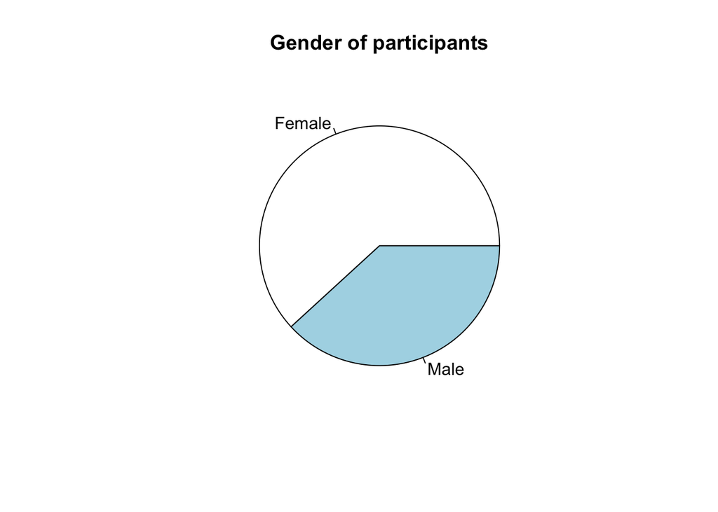

```r
pie(table(Czech_Republic_data$q_0001), main ="Gender of participants")
```

## Age

```r
summary(Czech_Republic_data$q_0002)
```

```
##    Min. 1st Qu.  Median    Mean 3rd Qu.    Max.    NA's
##   26.00   29.00   31.00   31.24   32.00   54.00       3
```

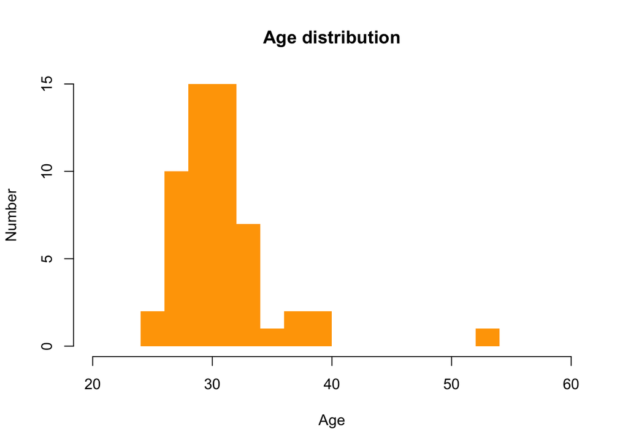

```r
hist(Czech_Republic_data$q_0002, col="orange",
     xlab="Age",
     ylab="Number",
     main="Age distribution",
     border=NA,
     breaks=c(seq(20,60,2)))
```

```r
table(Czech_Republic_data$q_0003)
```

```
##
##                                                  Year 1
##                                                       1
##                                                  Year 2
##                                                       7
##                                                  Year 3
##                                                       6
##                                                  Year 4
##                                                       9
##                                                  Year 5
##                                                       7
##                                                  Year 6
##                                                       5
##                                                  Year 7
##                                                       5
##                                                  Year 8
##                                                       1
##                           More than 8 years in training
##                                                       1
## I have recently finished training (within last 5 years)
##                                                      13
```

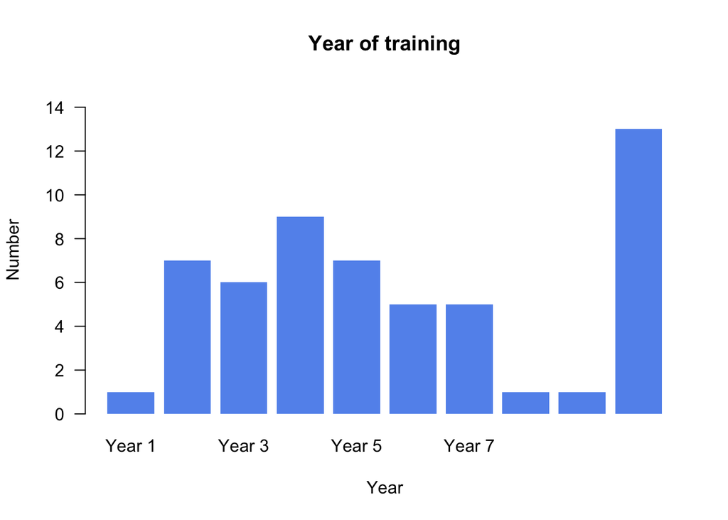

```r
barplot(table(Czech_Republic_data$q_0003), ylim = c(0,15), main="Year of training", xlab="Year", las=1, col="cornflowerblue", border=NA, ylab="Number")
```

## Are you receiving personal psychotherapy or have you received it in the past?

```r
# TODO : GGPLOT this : http://docs.ggplot2.org/current/geom_bar.html
Czech_Republic_data[, 7] <- as.numeric(Czech_Republic_data[, 7])
attributes(Czech_Republic_data)$variable.labels[7] <- "Are you receiving personal psychotherapy or have you received it in the past?"
Czech_Republic_data[, 7] <- factor(Czech_Republic_data[, 7], levels=c(1,2),labels=c("Yes","No"))
names(Czech_Republic_data)[7] <- "q_0004"
table(Czech_Republic_data$q_0004)
```

```
##
## Yes  No
##  21  34
```

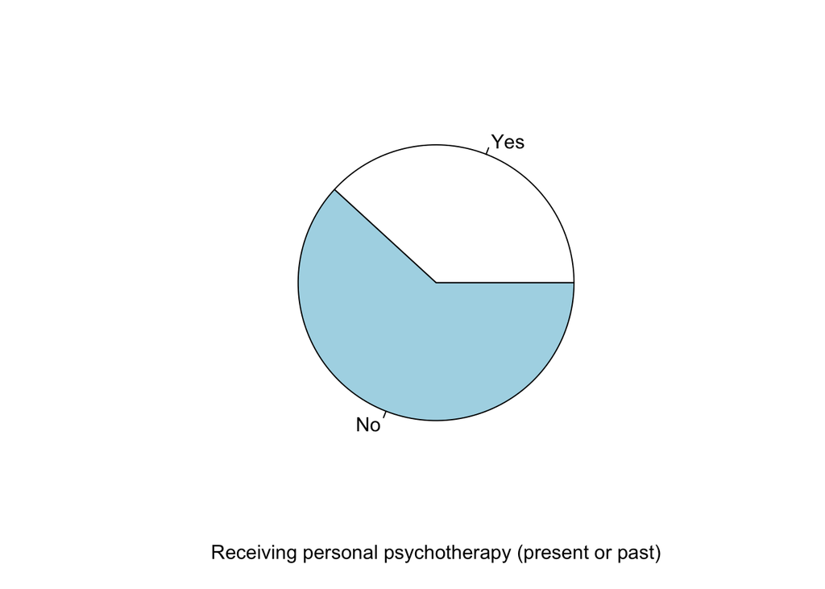

```r
pie(table(Czech_Republic_data$q_0004), xlab="Receiving personal psychotherapy (present or past)")
```

## I am undertaking training in Psychotherapy within my training programme in Psychiatry

```r
#tab <- table(Czech_Republic_data$q_0005_S05A1)
#pie(tab)
#pie(table(Czech_Republic_data$q_0005_S05A1))
 #   , xlab="In a Psychotherapy training within my training programme")
```

## I am undertaking training in Psychotherapy on my own initiative

```r
table(Czech_Republic_data$q_0005_S05A2)
```

```
##
##          Yes Not selected
##           31           27
```

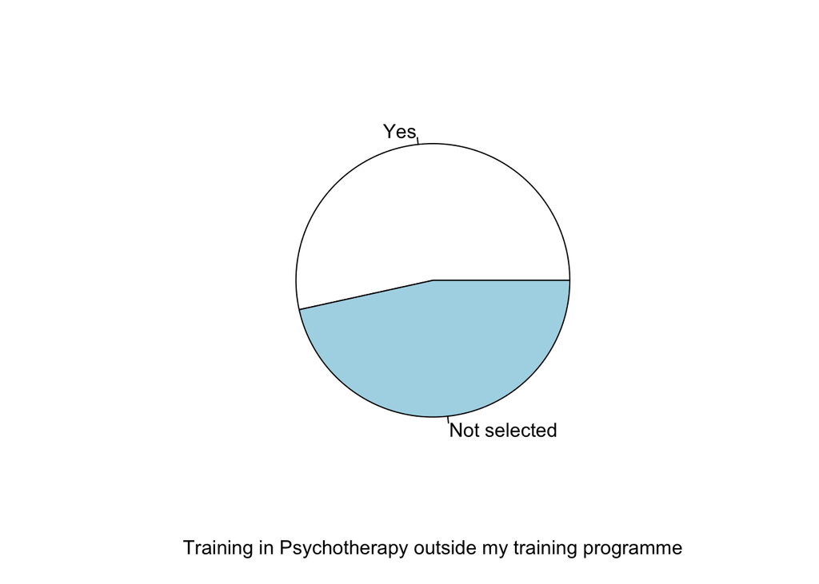

```r
pie(table(Czech_Republic_data$q_0005_S05A2),
  xlab="Training in Psychotherapy outside my training programme")
```

## I am not undertaking any training in Psychotherapy

```r
table(Czech_Republic_data$q_0005_S05A3)
```

```
##
##          Yes Not selected
##           17           41
```

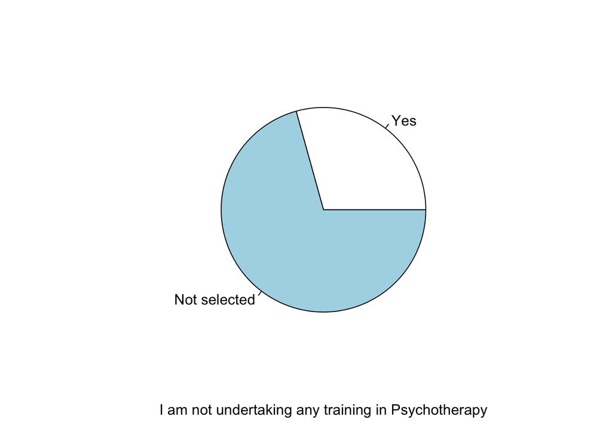

```r
pie(table(Czech_Republic_data$q_0005_S05A3),
  xlab="I am not undertaking any training in Psychotherapy")
```

> Psychotherapy training taking place within working hours is recommended by UEMS as a mandatory component of curriculum.

## I have completed full training in a Psychotherapy specialty in the past

```r
table(Czech_Republic_data$q_0005_S05A4)
```

```
##
##          Yes Not selected
##            4           54
```

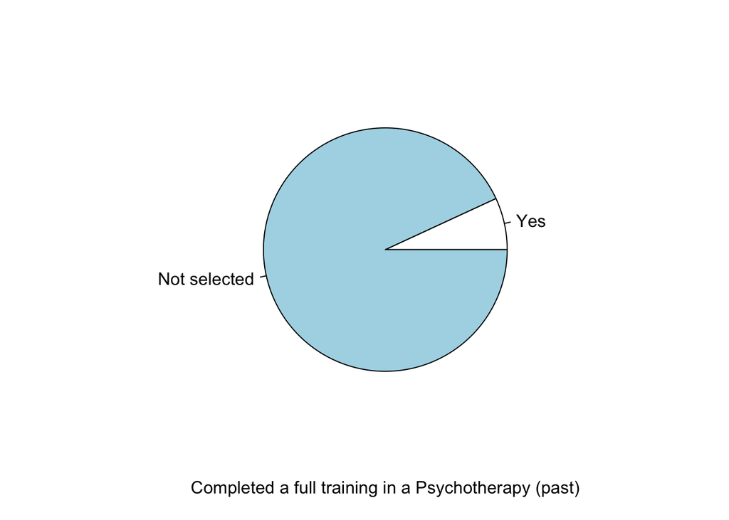

```r
pie(table(Czech_Republic_data$q_0005_S05A4), xlab="Completed a full training in a Psychotherapy (past)")
```

## I am training in some modality

```r
table(is.na(Czech_Republic_data$q_0006))
```

```
##
## FALSE  TRUE
##    36    22
```

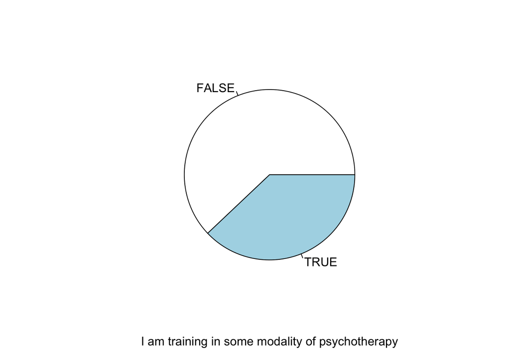

```r
pie(table(is.na(Czech_Republic_data$q_0006)),xlab="I am training in some modality of psychotherapy")
```

## Is psychotherapy important for your identity as a psychiatrist ?

```r
table(Czech_Republic_data$q_0007)
```

```
##
## Yes  No
##  51   4
```

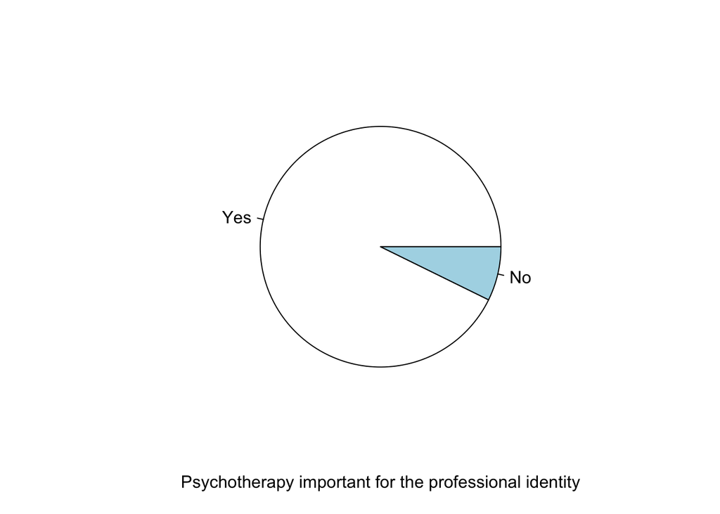

```r
pie(table(Czech_Republic_data$q_0007), xlab="Psychotherapy important for the professional identity")
```

## Do you want to practise Psychotherapy ?

```r
table(Czech_Republic_data$q_0008)
```

```
##
## Yes  No
##  49   6
```

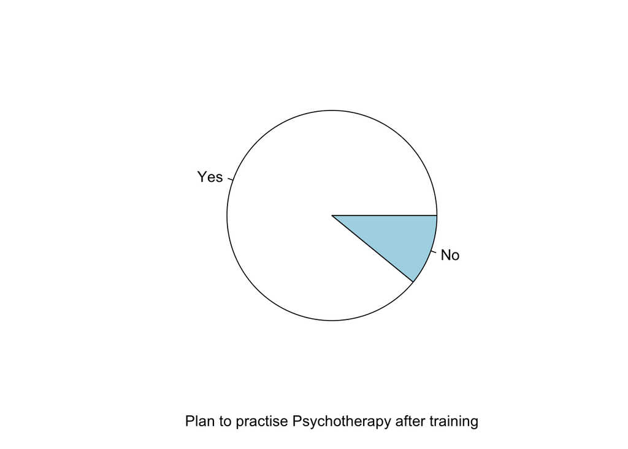

```r
pie(table(Czech_Republic_data$q_0008), xlab="Plan to practise Psychotherapy after training")
```

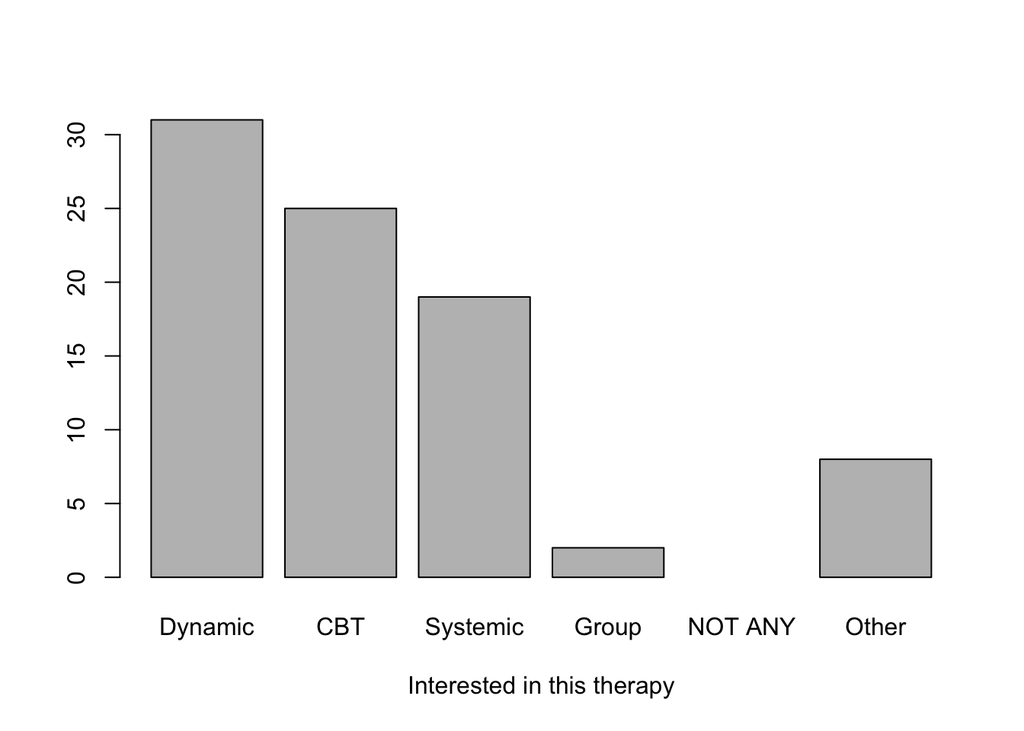

```r
q9df <- Czech_Republic_data[,16:21]
barplot(c(sum(q9df[,1]=="Yes"), sum(q9df[,2]=="Yes"), sum(q9df[,3]=="Yes"), sum(q9df[,4]=="Yes"),
         sum(q9df[,5]=="Yes"), sum(!is.na(q9df[,6]))),
        names.arg=c("Dynamic","CBT","Systemic","Group","NOT ANY","Other"),xlab="Interested in this therapy")
```